# PRACTICAL WORK

Proposed by

**PATRICK VALDURIEZ & CARLYNA BONDIOMBOUY**

IMSP-INRIA

## Linux/UNIX Install

This document describes how to install Python 3.7, Java 8, Spark 2.3.0, and Anaconda3-5.3.1 on Ubuntu Linux machines.

1. *Python*

To see which version of Python 3 you have installed, open a command prompt and run

[output not shown]

#### Sources :

https://docs.python-guide.org/starting/install3/linux/

https://docs.python-guide.org/dev/virtualenvs/#virtualenvironments-ref

https://doc.ubuntu-fr.org/python

1. *Spark*

Spark is Hadoop’s sub-project. Therefore, it is better to install Spark into a Linux based system. The following steps show how to install Apache Spark.

Step 1: Verifying Java Installation

Java installation is one of the mandatory things in installing Spark. Try the following command to verify the JAVA version.

[output not shown]

## Windows Install

This document describes how to install Python 3.7, Java 8, Spark 2.3.0, and Anaconda3-5.3.1 on Windows machines.

### Python

1. Double-click the icon labeling the file python-3.7.0.exe.

An Open File - Security Warning pop-up window will appear.

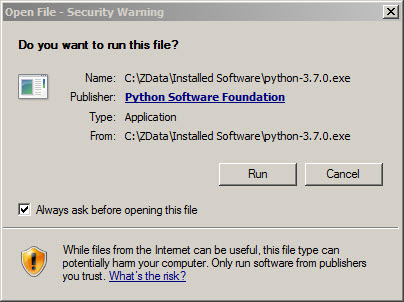

```python
from IPython.display import Image
Image(filename='C:/Users/carlyna.bondiombouy/Desktop/IMSP SPARK/python1.png')
```

1. Click Run. A Python 3.7.0 (32-bit) Setup pop-up window will appear.

[figure not shown]

```python
from IPython.display import Image
Image(filename='C:/Users/carlyna.bondiombouy/Desktop/IMSP SPARK/python2.png')
```

Ensure that the Install launcher for all users (recommended) and the Add Python 3.7 to PATH checkboxes at the bottom are checked.

If the Python Installer finds an earlier version of Python installed on your computer, the Install Now message may instead appear as Upgrade Now (and the checkboxes will not appear).

1. Highlight the Install Now (or Upgrade Now) message, and then click it.

A User Account Conrol pop-up window will appear, posing the question Do you want the allow the following program to make changes to this computer?

[figure not shown]

```python
from IPython.display import Image
Image(filename='C:/Users/carlyna.bondiombouy/Desktop/IMSP SPARK/python3.png')
```

1. Click the Yes button.

A new Python 3.7.0 (32-bit) Setup pop-up window will appear with a Setup Progress message and a progress bar.

During installation, it will show the various components it is installing and move the progress bar towards completion. Soon, a new Python 3.7.0 (32-bit) Setup pop-up window will appear with a Setup was successfuly message.

1. Click the Close button.

Python should now be installed. Verifying To try to verify installation,

```
1.  Navigate to the directory C:\Users\Pattis\AppData\Local\Programs\Python\Python37-32 (or to whatever directory Python was installed: see the pop-up window for Installing step 3).
2.  Double-click the icon/file python.exe.
```

A pop-up window with the title C:\Users\IMSP\AppData\Local\Programs\Python\Python37-32 appears, and inside the window; on the first line is the text Python 3.7.0 ... (notice that it should also say 32 bit). Inside the window, at the bottom left, is the prompt >>>: type exit() to this prompt and press enter to terminate Python.

You should keep the file python-3.7.0.exe somewhere on your computer in case you need to reinstall Python (not likely necessary).

You may now follow the instructions to download and install Java (you should have already installed Java, but if you haven't, it is OK to do so now, so long as you install both Python and Java before you install Eclipse), and then follows the instruction to download and install the Eclipse IDE. Note: you you need to download/install Java even if you are using Eclipse only for Python)

#### Source :

https://www.ics.uci.edu/~pattis/common/handouts/pythoneclipsejava/python.html

### Java

1. Install Java jdk
2. Install Scala
3. Download Winutils
4. Install Anaconda – as an IDE for Python development
5. Install Spark

Installing Spark requires adding a number of environment variables so there is a small section at the beginning explaining how to add an environment variable.

*Create Environment Variables*

To install Spark you need to add a number of environment variables. The following shows how to create an environment variable in Windows 10:

[figure not shown]

```python
from IPython.display import Image
Image(filename='C:/Users/carlyna.bondiombouy/Desktop/IMSP SPARK/java1.png')
```

In Control Panel, click on System and Security:

[figure not shown]

```python
from IPython.display import Image
Image(filename='C:/Users/carlyna.bondiombouy/Desktop/IMSP SPARK/java2.png')
```

In the next pane, click on System:

[figure not shown]

```python
from IPython.display import Image
Image(filename='C:/Users/carlyna.bondiombouy/Desktop/IMSP SPARK/java3.png')
```

In the system pane, click on Advanced system settings:

[figure not shown]

```python
from IPython.display import Image
Image(filename='C:/Users/carlyna.bondiombouy/Desktop/IMSP SPARK/java4.png')
```

In system Properties, click on Environment Variables…

*Install Java jdk*

Make sure you have the latest version of Java installed; if you do, you should have the latest version of the Java jdk. If not, download the jdk from the following link:

http://www.oracle.com/technetwork/java/javase/downloads/index.html

Once downloaded, copy the jdk folder to C:\Program files\Java:

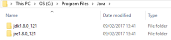

```python
from IPython.display import Image
Image(filename='C:/Users/carlyna.bondiombouy/Desktop/IMSP SPARK/java6.png')
```

Create an environment variable called JAVA_HOME and set the value to the folder with the jdk in it (e.g. C:\Program Files\Java\jdk1.8.0_121):

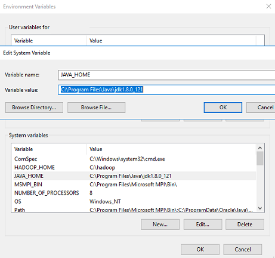

```python
from IPython.display import Image
Image(filename='C:/Users/carlyna.bondiombouy/Desktop/IMSP SPARK/java7.png')
```

### Install Scala

Install Scala from this location:

http://www.scala-lang.org/download/2.10.5.html

Download the msi and run it on the machine. Create an environment variable called SCALA_HOME and point it to the directory where Scala has been installed:

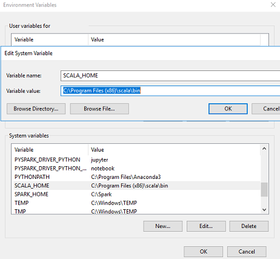

```python
from IPython.display import Image
Image(filename='C:/Users/carlyna.bondiombouy/Desktop/IMSP SPARK/java8.png')
```

### Download Winutils

Download the winutils.exe binary from this location:

https://github.com/steveloughran/winutils/blob/master/hadoop-2.7.0/bin/winutils.exe

1. Create the following folder and save winutils.exe to it: c:\hadoop\bin
2. Create an environment variable called HADOOP_HOME and give it the value C:\hadoop
3. Edit the PATH environment variable to include %HADOOP_HOME%\bin:

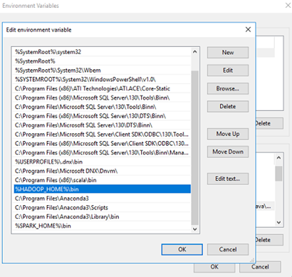

```python
from IPython.display import Image
Image(filename='C:/Users/carlyna.bondiombouy/Desktop/IMSP SPARK/hadoop.png')
```

1. Create tmp\hive directory
2. Create a folder called hive in the following location: C:\tmp\hive
3. Run the following line in Command Prompt to put permissions onto the hive directory:

`Python winutils.exe chmod -R 777 C:\tmp\hive`

You can check permissions with the following command:

`Python winutils.exe ls \tmp\hive`

### Install Anaconda

https://repo.continuum.io/archive/index.html

If possible, make sure Anaconda is saved to the following folder: C:\Program Files\Anaconda3

Add an environment variable called PYTHONPATH and give it the value of where Anaconda is saved to:

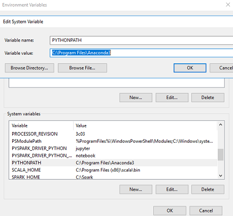

```python
from IPython.display import Image
Image(filename='C:/Users/carlyna.bondiombouy/Desktop/IMSP SPARK/anaconda.png')
```

### Spark

*Download Spark:*

Download the latest version of Spark from the following link. Make sure the package type says pre-built for Hadoop 2.7 and later. http://spark.apache.org/downloads.html

1. Once downloaded, change the extension of the file from tar to zip, so that the file name reads spark-2.x.0-bin-hadoop2.7.zip.

   ```
    a. Extract the file using winrar or winzip.
   ```

2. Within the extracted folder is a file without an extension.

   ```
    a. Add a zip extension to the file and extract again.
   ```

3. Create a folder at C:\Spark and copy the contents of the second extracted folder to it.
4. Change log4j.properties file.

   ```
    a. Go to the folder C:\Spark\conf and open the file log4j.properties.template using WordPad.

    b. Find the log4j.rootCategory setting and change it from INFO to WARN.
   ```

5. Save the changes to the file.
6. Remove the template extension from the file name so that the file name becomes log4j.properties
7. Add Spark Environment Variables

   Add an environment variable called SPARK_HOME and give it the value of the folder where Spark was downloaded to (C:\Spark):
8. Add to the PATH Environment variable the following value: %SPARK_HOME%\bin
9. Environment variables

   ```
    a. Add Environment Variables to open Spark with Jupyter notebook

    b. Add the following variables if you want the default program that opens with Spark to be Jupyter Notebooks.

    c. Add the environment variable PYSPARK_DRIVER_PYTHON and give it the value jupyter.

    d. Add the environment variable PYSPARK_DRIVER_PYTHON_OPTS and give it the value notebook.
   ```

10. Open Spark

    ```
    a. To use Spark, open command prompt, then type in the following two commands: CD C:\Spark\bin

    b. Pyspark
    ```

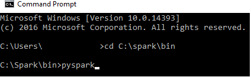

```python
from IPython.display import Image
Image(filename='C:/Users/carlyna.bondiombouy/Desktop/IMSP SPARK/spark1.png')
```